# TP1 Statistiques avec R 1A 2025-2026

Lien Onyxia et Git, document Quarto, rappels du S1

Auteur·rice

Brandon SAINTILAN

## Introduction

### Présentation du Datalab

**Aujourd’hui, nous allons travailler non pas sur le cluster de l’Ensai mais sur le** [Datalab SSP Cloud](https://datalab.sspcloud.fr/), ouverts à tous les agents publics et à tous les étudiants de l’Ensai (en utilisant votre mail eleve.ensai.fr). Le Datalab est un autre moyen de travailler sur Rstudio. Une fois connecté, son fonctionnement est identique à celui du cluster que vous avez utilisé au 1er semestre. La différence réside dans le fait que **votre session sur le Datalab n’est valable qu’environ 7 jours : ensuite, vos documents seront supprimés !**

Globalement, ce service vous permettra d’accéder à RStudio (et plein d’autres services…) directement via un navigateur (sans avoir à l’installer en local donc) et sans faire souffrir les performances de votre ordinateur.

**Avertissement**

Ne déposez pas de données sensibles sur cette instance, ni sur celle du GENES.

Pour celles et ceux qui iront à l’INSEE, une autre instance nommée LS3 (accessible qu’en interne) autorise l’utilisation de données sensibles.

### Et Git alors ?

Généralement, on utilise le Datalab en association avec des outils tels que **Git**. Git (“Github”, “Gitlab”) est très répandu en milieu professionnel pour le travail collaboratif. C’est ce que l’on appelle un **outil de versionning**. Git permet de suivre l’historique des modifications d’un projet, notamment pour le code. Il permet de garder une trace de chaque changement apporté au projet, de revenir à une version antérieure si nécessaire, et de travailler à plusieurs sur le même projet sans écraser le travail des autres. En résumé, il va vous permettre de :

- **sauvegarder régulièrement votre travail**
- **revenir à une version précédente en cas d’erreur**
- **collaborer facilement avec d’autres sans se marcher sur les pieds**

Le but de ce TP n’est pas de vous former à Git, vous aurez (ou avez eu) un TP dessus dans le cadre d’une autre matière. Cependant, vous devez savoir que Rstudio permet de travailler facilement avec Git. Dans le cadre de ce TP, nous utiliserons Github pour lequel vous avez déjà du créer un compte. Si ce n’est pas le cas, c’est [ici](https://github.com/signup).

Le TP se déroulera en 3 phases :

- 1. Tutoriel : comment associer GitHub et RStudio grâce à Onyxia
- 2. Quarto : le document mêlant du texte et du code R exécutable facilement
- 3. Rappels du S1 : le package `dplyr

## 1 Tutoriel lien Onyxia et Git

**Commencez par vous connecter (ou vous inscrire) au Datalab … :**

- … en accédant à la [page du Datalab SSP Cloud (Onyxia)](https://datalab.sspcloud.fr/)

**Mise en garde**

Il est important d’utiliser votre mail **prenom.nom@eleve.ensai.fr** pour vous inscrire sur Onyxia !

### 1.1 Créez votre dépôt Github

- Connectez-vous à votre compte [Github](https://github.com/login)
- Cliquez sur votre profil (icone en haut à droite) et allez dans Repositories :

[figure not shown]

Figure 1: Accès aux repositories

**NoteC’est quoi un repo ?**

Un repository Git (ou repo) est un espace de stockage où l’on conserve un projet, son historique et toutes les versions du code. Cela permet de suivre les changements, de revenir en arrière si besoin, et de collaborer facilement avec d’autres développeurs. C’est comme un dossier pour le code, mais avec des outils pour gérer les modifications et l’évolution du projet.

- Créez un dépôt (New Repository) : cliquez sur le bouton vert “New” ou cliquez sur le bouton “+” puis “New repository”
- Renseignez ce “new repository” en lui donnant le nom **“Stats_avec_R”**. Cliquez sur “Private” et “Add a README file”. Vous pouvez rajouter une description si vous le souhaitez.
- Dans la rubrique “.gitignore”, sélectionnez l’option “R” afin de spécifier à Git quels fichiers il ne doit pas suivre.

**NoteC’est quoi le .gitignore ?**

Le fichier **.gitignore** est une liste de règles qui indiquent à Git **quels fichiers ou répertoires doivent être ignorés et ne pas être ajoutés à l’historique de version** de votre projet.

Par exemple, dans un projet RStudio, vous ne voulez probablement pas que Git suive les fichiers temporaires générés par R, comme les fichiers .Rhistory, .RData, ou les répertoires .Rproj.user. Ceux-ci ne sont pas utiles pour l’historique du projet, car ils sont spécifiques à votre environnement local.

En choisissant l’option “R” lors de la création du repo, le fichier .gitignore créé contient ce qui suit :

```r
# History files
# FR : Ignorer les fichiers d'historique des commandes R
.Rhistory
.Rapp.history

# Session Data files
# FR : Ignorer les fichiers contenant les données de session R
.RData
.RDataTmp

# User-specific files
# FR : Ignorer les fichiers spécifiques à l'utilisateur et à l'environnement R local
.Ruserdata

# Example code in package build process
# FR : Ignorer les fichiers d'exemple créés lors du processus de construction du package
*-Ex.R

# Output files from R CMD build
# FR : Ignorer les fichiers de sortie générés par la commande `R CMD build` (fichier archive du package)
/*.tar.gz

# Output files from R CMD check
# FR : Ignorer les fichiers générés par la commande `R CMD check` (répertoire de vérification du package)
/*.Rcheck/

# RStudio files
# FR : Ignorer les fichiers et répertoires spécifiques à RStudio
.Rproj.user/

# produced vignettes
# FR : Ignorer les fichiers de vignettes générées (par exemple en HTML ou PDF)
vignettes/*.html
vignettes/*.pdf

# OAuth2 token, see <https://github.com/hadley/httr/releases/tag/v0.3>
# FR : Ignorer le fichier contenant le token OAuth2 pour des raisons de sécurité
.httr-oauth

# knitr and R markdown default cache directories
# FR : Ignorer les répertoires de cache générés par `knitr` et R Markdown
*_cache/
/cache/

# Temporary files created by R markdown
# FR : Ignorer les fichiers temporaires générés pendant le rendu d'un document R Markdown
*.utf8.md
*.knit.md

# R Environment Variables
# FR : Ignorer le fichier `.Renviron` qui contient les variables d'environnement spécifiques à R
.Renviron

# pkgdown site
# FR : Ignorer le répertoire contenant les fichiers générés par `pkgdown` pour la documentation du package
docs/

# translation temp files
# FR : Ignorer les fichiers temporaires générés lors de la traduction (fichiers `.po`)
po/*~

# RStudio Connect folder
# FR : Ignorer le répertoire contenant les fichiers spécifiques à RStudio Connect, utilisé pour déployer des applications R
rsconnect/
```

- Cliquez enfin sur “Create repository”.

[figure not shown]

Figure 2: Créer un nouveau repo

Nous obtenons ainsi notre premier repo sous Github initulé **Stats_avec_R** :

[figure not shown]

Figure 3: New Repo créé (2)

### 1.2 Récupérez votre token Github

**AvertissementVous avez déjà un token suite au TP Git ?**

Pour ceux ayant respecté les consignes du TP Git proposé par Ludovic Deneuville, vous avez déjà un token actif jusqu’au 30/06/2026 : https://ludo2ne.github.io/Git-tuto/doc/tp-ensai.html#g%C3%A9n%C3%A9ration-dun-token. Il vous suffit donc de bien vérifier… :

- … que le token est actif dans GitHub
- … que c’est bien un token classic (ghp_xxxxx) et pas un autre token
- … qu’il est bien déclaré sur Onyxia rubrique “Mon Compte” (voir plus loin)

**NoteUn token ??**

Un token GitHub est une clé secrète utilisée pour accéder à un repository GitHub de manière sécurisée, sans avoir besoin de taper votre mot de passe Github à chaque action. Il permet en quelque sorte de connecter votre dépôt Github à votre session Rstudio.

- Cliquez sur votre profil (icone en haut à droite), puis “Settings”.

[figure not shown]

Figure 4: Accès à Developper Settings

- Cliquez sur “Developer settings” (dernier onglet en bas à gauche dans le menu déroulant).
- Cliquez sur “Personal access token” puis sur “Tokens(classic)”.
- Cliquez sur “Generate new token” puis sur “Generate new token (classic)”.
- Renseignez “Note” avec un nom, par exemple **“Onyxia_Datalab”**.
- Choisissez une date d’expiration du token : “Custom” puis “13-01-2027”
- Dans la partie “Select scopes”, cliquez uniquement sur “repo”
- Cliquez sur le bouton vert “Generate token” tout en bas de la page, puis **copier le token !**

**AvertissementATTENTION ! Copiez votre token !**

Attention : sa valeur ne sera affichée qu’une seule fois. En cas de perte, il faut le supprimer et en recréer un nouveau.

[figure not shown]

Figure 5: Générer un nouveau token

### 1.3 Renseignez les informations sur Onyxia

- Allez sur l’onglet “Mon compte” sur le côté gauche puis sur l’onglet “Git”.
- Si ce n’est pas fait par défaut, renseignez votre **nom d’utilisateur + mail Git**.
- Renseignez ensuite votre “Token d’accès personnel pour Forge Git” en **collant le token précédemment généré**

[figure not shown]

Figure 6: Coller le token généré

**Retour rapide sur Github :**

- Retournez sur votre repo “Stats_avec_R”. Cliquez sur le bouton vert Code, et **copiez le lien https de votre repo**. Vous obtenez une url de ce type : `https://github.com/<username>/Stats_avec_R.git`

[figure not shown]

Figure 7: Récupérer lien HTTPS du repo

### 1.4 Lancement de votre session Rstudio

- Toujours sur Onyxia, cliquez sur “Mes services” puis “+ Nouveau service”
- Dans le cadre “Rstudio”, cliquez sur “Lancer”
- Vous arrivez sur la page de configuration de votre Rstudio. Faites défilez puis cliquez sur l’onglet “GIT”
- **Renseignez ensuite le champ “Repository” en collant le lien https de votre repo précédemment copié**
- Cliquez enfin sur le bouton “Lancer” puis patientez quelques secondes.

[figure not shown]

Figure 8: Coller le https du repo dans Onyxia

- Cliquez sur “Copier le mot de passe” puis “Ouvrir le service”

[figure not shown]

Figure 9: Accès RStudio depuis Onyxia

**AstuceID et mdp svp ?**

Le nom d’utilisateur est le même pour tout le monde : onyxia. Le mot de passe est propre à chacun et à chaque session, inutile de le conserver.

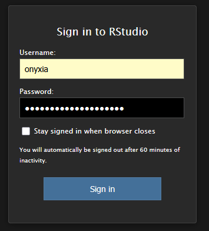

Figure 10: id et mdp Onyxia

### 1.5 L’onglet Git apparait !

Votre session est enfin prête. Vous remarquerez dans le cadran en haut à droite un onglet que vous n’aviez pas dans le cluster Ensai : l’onglet Git. C’est lui qui va vous simplifer la vie et vous permettre de suavgearder le plus regulièrement possible votre code.

**NoteSI vous ne voyez pas l’onglet GIT…**

- Créez un projet en cliquantr sur File > New Project > Existing Directory, puis choisir le dossier “Stats_avec_R”

Dans le cadran inférieur droit, onglet “Files”, on remarque que notre repo Github est entièrement chargé (fichiers READEME + gitignore), signifiant que l’association avec Git est réussie. Vous verrez également un troisième fichier : le `Stats_avec_R.RProj` qui s’est automatiquement créé.

[figure not shown]

Figure 11: Onglet Git et Repo importé dans RStudio

**NoteSI vous rencontrez des problèmes…**

Si vous rencontrez des difficultés pour relier votre repo à RStudio, vérifiez bien… :

- … que le token est actif dans GitHub
- … que le token est bien déclaré sur Onyxia dans “Mon Compte”
- … que c’est bien un token classic (ghp_xxxxx) et pas un autre token

1. Via l’invité de commandes Git de RStudio :
- Copiez votre lien https du repo depuis GitHub. Vous obtenez une url de ce type : `https://github.com/<username>/Stats_avec_R.git`
- Modifiez le lien copié en y intégrant votre token avant *github.com* : `https://$GIT_PERSONAL_ACCESS_TOKEN@github.com/<username>/Stats_avec_R.git`
- Dans l’interface RStudio, utiliser l’onglet “Terminal” situé au niveau de la console, puis tapez : `git clone <url ci-dessus>` afin de cloner le repo “Stats_avec_R” existant dans Github.

Remarque : une fois un repo cloné, l’instruction `git remote -v` permet de vérifier sur quel dépôt distant votre clone est branché.

[figure not shown]

Figure 12: Version Control dans RStudio

En cas de besoin, vous pouvez vous reporter :

- au [TP de Ludovic Deneuville sur Git](https://ludo2ne.github.io/Git-tuto/doc/tp-ensai.html#cr%C3%A9ez-un-d%C3%A9p%C3%B4t-local) dans la section dédiée à la création d’un dépôt local
- à la [page dédiée au contrôle de version de Lino Galiana du SSPLab](https://linogaliana.gitlab.io/collaboratif/git.html#la-premi%C3%A8re-fois)

### 1.6 Et donc, comment sauvegarder notre code sous Github ?

Ce troisième fichier `Stats_avec_R.RProj` n’est pas encore connu sous Github (vous pouvez vous en assurer en consultant à cette étape vore repository initial). Pour le sauvegarder, on va **commit-push** via l’onglet Git.

**NoteCommit + Push ??**

Commit et Push sont deux étapes importantes dans l’utilisation de Git pour gérer un projet.

Un **“commit”** consiste à enregistrer les modifications que vous avez faites dans votre projet, de manière locale sur votre ordinateur. Cela permet de créer un “instantané” de votre travail à un moment donné. Lorsque vous faites un commit, vous ajoutez un message pour décrire ce que vous avez changé.

Un *“Push”** sert à envoyer ces changements (commits) vers votre repository distant sous GitHub. Cela permet de partager votre travail avec d’autres personnes ou de le sauvegarder sur le cloud. Ainsi, plus de perte de données possibles. Et aussi, possibilité de revenir à une version antérieure dans votre code !

En résumé :

- Commit = Sauvegarder les changements sur votre ordinateur.
- Push = Envoyer ces changements sur un serveur (ici GitHub) pour les partager.
- Dans l’onglet Git (1), ✅ cochez le nouveau fichier `Stats_avec_R.RProj` puis cliquez sur `Commit` (3)
- Renseignez un message associé à votre nouvelle action à sauvegarder (4)
- Cliquez sur `Commit`, puis `Close`
- Cliquez sur ⬆️ `Push` (6) pour envoyer votre commit sur le cloud Github/votre repo.

[figure not shown]

Figure 13: 1er push dans RStudio

Vérifions en retournant sur Github :

[figure not shown]

Figure 14: Changements dans Git

### 1.7 Pour aller plus loin

- Un [TP complet “Découverte du Datalab”](https://ludo2ne.github.io/ENSAI-1A-SQL/doc/outils/tp-datalab.html) (qui m’a d’ailleurs été d’une grande aide pour ce TP) proposé par Ludovic DENEUVILLE, assistant d’enseignement à l’Ensai. Il propose également d’autres contenus très intéressants [sur sa page GitHub](https://ludo2ne.github.io/).
- Les [principes du Datalab](https://docs.sspcloud.fr/content/principles.html). Si vous avez besoin d’assistance, vous pouvez contacter l’équipe du SSP Cloud sur [Slack](https://join.slack.com/t/3innovation/shared_invite/zt-1bo6y53oy-Y~zKzR2SRg37pq5oYgiPuA) ou directement par mail
- La [page GitHub du projet Onyxia](https://github.com/InseeFrLab/onyxia)
- Les [formations et tutoriels proposées par le SSP Cloud](https://www.sspcloud.fr/formation)
- La [page dédiée au contrôle de version de Lino Galiana du SSPLab](https://linogaliana.gitlab.io/collaboratif/git.html#la-premi%C3%A8re-fois)